#Лабораторный практикум ВКИАД c R

**Преподаватель**

```
Дернакова Оксана Владимировна
```

**Студент**

```
Колячко Мария Николаевна, 2 курс, 8 группа, ПМ
```

**Вариант № 6**

### Часть 1. Управление данными в R

Ввести данные из текстового файла согласно варианту (функция “read.table”). Сохранить в переменную qc (таблица данных).

```r
qc <- read.table("QC6.txt")
```

Вывести размерность таблицы данных(dim).

```r
dim(qc)
```

```
## [1] 100   9
```

Вывести первые 3 записи таблицы (head).

```r
head(qc, 3)
```

```
##      V1 V2 V3 V4 V5    V6     V7     V8 V9
## 1 10.58  4  2  1  4 31.79 18.417 84.120  5
## 2  9.00  1  3  1  2 31.20 19.140 85.500  5
## 3 10.57  5  1  2  4 34.22 18.477 85.395  5
```

Изменить имена переменных в таблице (names) согласно: “б”-“kit”, “п”-“nbug”, “№изг”-“maker”, “№пост”-“vendor”, “№вд”-“bug”, “н” - последовательно проименовать как “c1”, “c2”, “c3”, “c4” (порядок переменных смотрите в файле Lab.pdf согласно Вашему варианту).  
Вывести часть таблицы функцией head.

```r
names(qc) <- c("C1", "kit", "nbug", "maker", "vendor", "C2", "C3",  "C4", "bug")
head(qc, 3)
```

```
##      C1 kit nbug maker vendor    C2     C3     C4 bug
## 1 10.58   4    2     1      4 31.79 18.417 84.120   5
## 2  9.00   1    3     1      2 31.20 19.140 85.500   5
## 3 10.57   5    1     2      4 34.22 18.477 85.395   5
```

Вывести общую статистику по переменной vendor (summary). Обращаться к переменной через “$”.

```r
summary(qc $ vendor)
```

```
##    Min. 1st Qu.  Median    Mean 3rd Qu.    Max.
##    1.00    1.75    2.00    2.49    4.00    4.00
```

Преобразовать переменную vendor в переменную-фактор (c помощью as.factor, для доступа к переменной обратиться к столбцу с помощью оператора [] или оператора [[]]).  
Вывести общую статистику для преобразованной переменной vendor.

```r
qc[, 5] <- as.factor(qc[, 5])
summary(qc[, 5])
```

```
##  1  2  3  4
## 25 28 20 27
```

Подсчитать количество изделий, у которых число некритических дефектов больше 3 функция sum и оператор условия).

```r
sum(qc $ nbug > 3)
```

```
## [1] 11
```

Вывести наблюдение(-я), для которого количество некритических дефектов равно максимальному (оператор [] к переменной qc, функция max).

```r
tmp <- qc[(qc[3] == max(qc[3])), ]
head(tmp)
```

```
##       C1 kit nbug maker vendor    C2     C3     C4 bug
## 15 10.16   3    6     2      1 31.69 18.006 80.895   2
## 72  9.85   7    6     1      1 30.27 18.930 85.785   3
```

### Часть 2. Описательная статистика и графический анализ

Присоединить таблицу данных qc к списку текущих переменных (attach). Далее обращаться к именам переменных напрямую.  
Загрузить дополнительную библиотеку (для вычисления коэффициентов асимметрии и эксцесса).

```r
attach(qc)
library("e1071")
```

В данном пункте статистики и графики выводятся только для переменной c1.

Вычислить среднее (mean) и медиану (median).

```r
mean(C1)
```

```
## [1] 9.9173
```

```r
median(C1)
```

```
## [1] 9.945
```

```r
quantile(C1, probs <- c(0, 0.5, 1))
```

```
##     0%    50%   100%
##  7.680  9.945 12.690
```

```r
IQR(C1)
```

```
## [1] 1.1875
```

Вывести комплексную статистику по переменной c1.

```r
summary(C1)
```

```
##    Min. 1st Qu.  Median    Mean 3rd Qu.    Max.
##   7.680   9.367   9.945   9.917  10.555  12.690
```

Вычислить дисперсию (var) для переменных c1 и 2 * c1 + 100 в указанном порядке. В выводе записать программно вычисленное отношение дисперсий данных переменных.

```r
var(C1)
```

```
## [1] 0.9124401
```

```r
var(2 * C1 + 100)
```

```
## [1] 3.64976
```

$Вывод:$ вторая дисперсия больше в 4 раза.

Вычислить дисперсию, используя векторное выражение (то есть в одну строку, без циклов).

```r
sum((C1 - sum(C1)/length(C1))^2 / (length(C1) - 1))
```

```
## [1] 0.9124401
```

Построить гистограмму (hist).

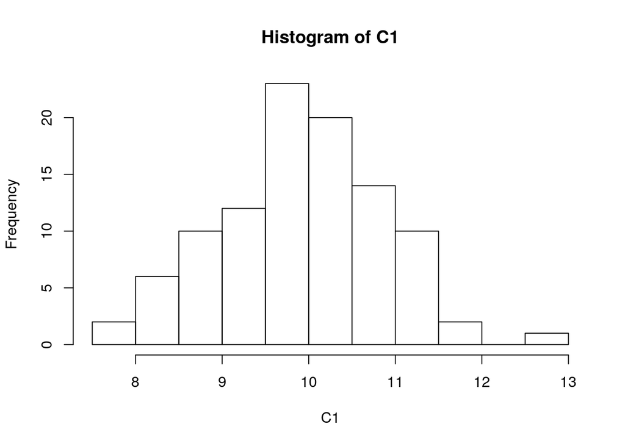

```r
hist(C1)
```

```r
skewness(C1)
```

```
## [1] 0.07216337
```

```r
kurtosis(C1)
```

```
## [1] -0.1389916
```

Проверить нормальность остатков с помощью статистического теста Лиллиефорса (lillie.test). Сделать вывод.

```r
library(nortest)
lillie.test(C1)
```

```
##
##  Lilliefors (Kolmogorov-Smirnov) normality test
##
## data:  C1
## D = 0.065679, p-value = 0.3592
```

$Вывод:$ гипотеза о нормальном распределении принимается на уровне значимости 0.05.

### Часть 3. Анализ статистических зависимостей

Перекодировать переменную kit так, чтобы она принимала только два значения: 1 и 2 (1 при kit < 3, 2 - в отстальных случаях).

```r
qc $ kit <- ifelse(qc $ kit < 3, 1, 2)
head(qc, 3)
```

```
##      C1 kit nbug maker vendor    C2     C3     C4 bug
## 1 10.58   2    2     1      4 31.79 18.417 84.120   5
## 2  9.00   1    3     1      2 31.20 19.140 85.500   5
## 3 10.57   2    1     2      4 34.22 18.477 85.395   5
```

Вычислить ранговый коэффициент корреляции Спирмена (cor, method = “spearman”) для переменных kit и maker.

```r
cor(kit, maker, method = "spearman")
```

```
## [1] 0.1164959
```

Вывести таблицу сопряженности (table) по переменным kit и maker. Сделать вывод.

```r
table(kit, maker)
```

```
##    maker
## kit  1  2
##   0  4  2
##   1 12  8
##   2 11 11
##   3 12 11
##   4  7  9
##   5  4  3
##   6  1  3
##   7  1  1
```

$Вывод: $ cогласно ранговому коэффициенту корреляции и таблице сопряженности согласованность между переменными практически отсутствует.

Для переменных c1, c3 вычислить коэффициент корреляции. Сделать вывод.

```r
cor.test(C1, C3)
```

```
##
##  Pearson's product-moment correlation
##
## data:  C1 and C3
## t = 5.8081, df = 98, p-value = 7.836e-08
## alternative hypothesis: true correlation is not equal to 0
## 95 percent confidence interval:
##  0.3437945 0.6389502
## sample estimates:
##       cor
## 0.5060409
```

$Вывод :$ гипотеза о равенстве нулю коэффициента корреляции между c1 и c3 отклоняется на уровне значимости = 0,05.

Вывести корреляционную матрицу по всем числовым характеристикам c1-c4 (cor). Для выбора нужных столбцов таблицы воспользоваться оператором “[]”.

```r
cor(qc[c("C1", "C2", "C3", "C4")])
```

```
##             C1          C2         C3         C4
## C1  1.00000000 -0.09152175  0.5060409  0.3867414
## C2 -0.09152175  1.00000000 -0.1960740 -0.2038993
## C3  0.50604092 -0.19607400  1.0000000  0.9045418
## C4  0.38674144 -0.20389934  0.9045418  1.0000000
```

Представить матрицу корреляции в более удобном виде(symnum, в качестве аргумента данной функции использовать результат функции cor). Сделать вывод.

```r
matrixCor <- cor(qc[c("C1", "C2", "C3", "C4")])
symnum(matrixCor)
```

```
##    C1 C2 C3 C4
## C1 1
## C2    1
## C3 .     1
## C4 .     *  1
## attr(,"legend")
## [1] 0 ' ' 0.3 '.' 0.6 ',' 0.8 '+' 0.9 '*' 0.95 'B' 1
```

$Вывод :$ наибольший коэффициент наблюдается между С4 и С3.

Построить модель линейной регрессии для пары переменных, для которых коэффициент корреляции имеет наибольшее значение. Использовать функцию lm, зависимая переменная - с меньшим номером. Полученную модель сохранить в переменную linmod. Вывести общую статистику по модели (summary). Сделать вывод.

```r
linmod <- lm(formula = C3 ~ C4)
summary(linmod)
```

```
##
## Call:
## lm(formula = C3 ~ C4)
##
## Residuals:
##      Min       1Q   Median       3Q      Max
## -0.73930 -0.19346 -0.01249  0.17648  0.69859
##
## Coefficients:
##             Estimate Std. Error t value Pr(>|t|)
## (Intercept)  1.43354    0.80250   1.786   0.0771 .
## C4           0.20392    0.00971  21.001   <2e-16 ***
## ---
## Signif. codes:  0 '***' 0.001 '**' 0.01 '*' 0.05 '.' 0.1 ' ' 1
##
## Residual standard error: 0.3118 on 98 degrees of freedom
## Multiple R-squared:  0.8182, Adjusted R-squared:  0.8163
## F-statistic:   441 on 1 and 98 DF,  p-value: < 2.2e-16
```

Вывод: коэффициент при зависимой переменной является статистически незначимым (на уровне 0.05). Коэффициент при независимой переменной является статистически значимым (на уровне 0.05). Статистика R-квадрат принимает значение 0.8182.

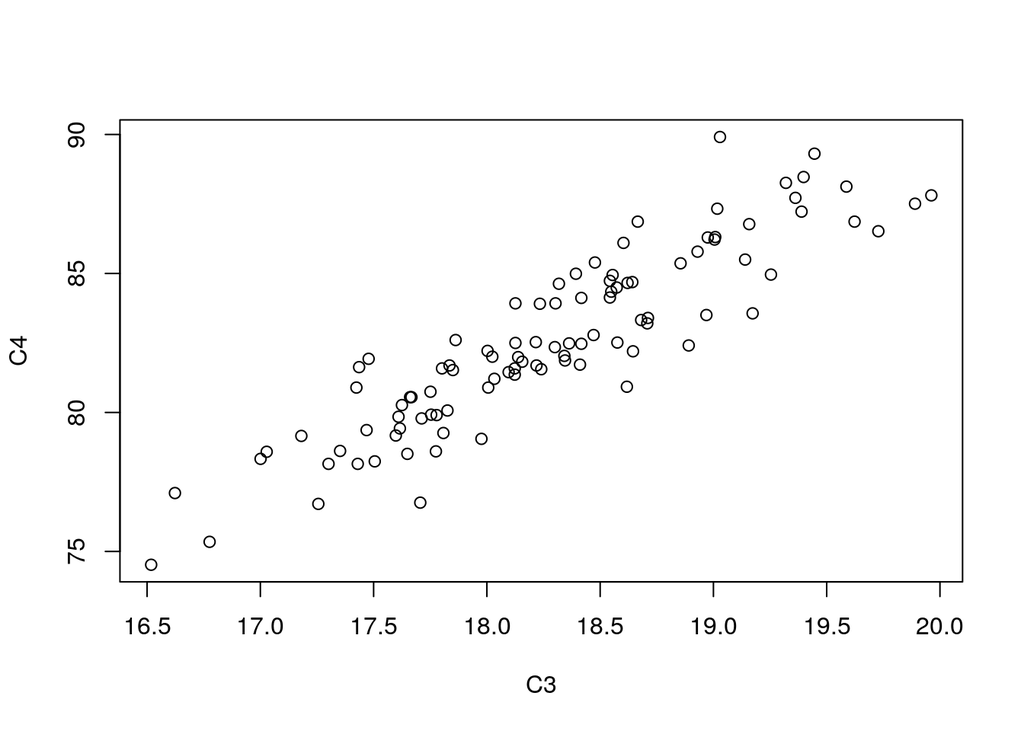

```r
plot(formula <- C4 ~ C3)
abline(linmod)
```

Вывести отдельно коэффициенты модели (coefficients).

```r
coefficients(linmod)
```

```
## (Intercept)          C4
##   1.4335366   0.2039235
```

Сохранить значения остатков (residuals) модели linmod в переменную res. Построить график “Квантиль-квантиль” (qqnorm) для остатков. Сделать вывод.

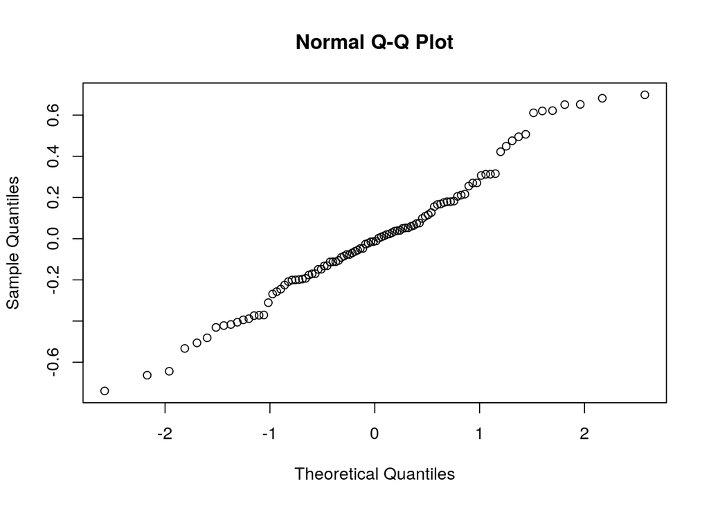

```r
res <- residuals(linmod)
qqnorm(res)
```

Вывод: Большинство точек располагаются вблизи прямой линии, поэтому распределение остатков близко к нормальному.

Проверить нормальность остатков с помощью статистического теста Колмогорова-Смирнова (ks.test).  
Сделать вывод.

```r
mn <- mean(res)
s <- sd(res)
ks.test(res, pnorm, mn, s)
```

```
##
##  One-sample Kolmogorov-Smirnov test
##
## data:  res
## D = 0.073138, p-value = 0.6586
## alternative hypothesis: two-sided
```

Вывод: Критерий принимает гипотезу о нормальном распределении остатков на уровне значимости 0.05.

### Часть 4. Анализ неоднородных данных

Подсчитать частоты значений для переменной maker (table).

```r
table(maker)
```

```
## maker
##  1  2
## 52 48
```

```r
t.test(C1 ~ maker)
```

```
##
##  Welch Two Sample t-test
##
## data:  C1 by maker
## t = 1.8562, df = 97.066, p-value = 0.06646
## alternative hypothesis: true difference in means is not equal to 0
## 95 percent confidence interval:
##  -0.02409981  0.72044596
## sample estimates:
## mean in group 1 mean in group 2
##        10.08442         9.73625
```

```r
#t.test(C2 ~ maker)
#t.test(C3 ~ maker)
#t.test(C4 ~ maker)
```

Построить “ящик с усами” для анализируемой переменной в разрезе по номеру производителя (maker).

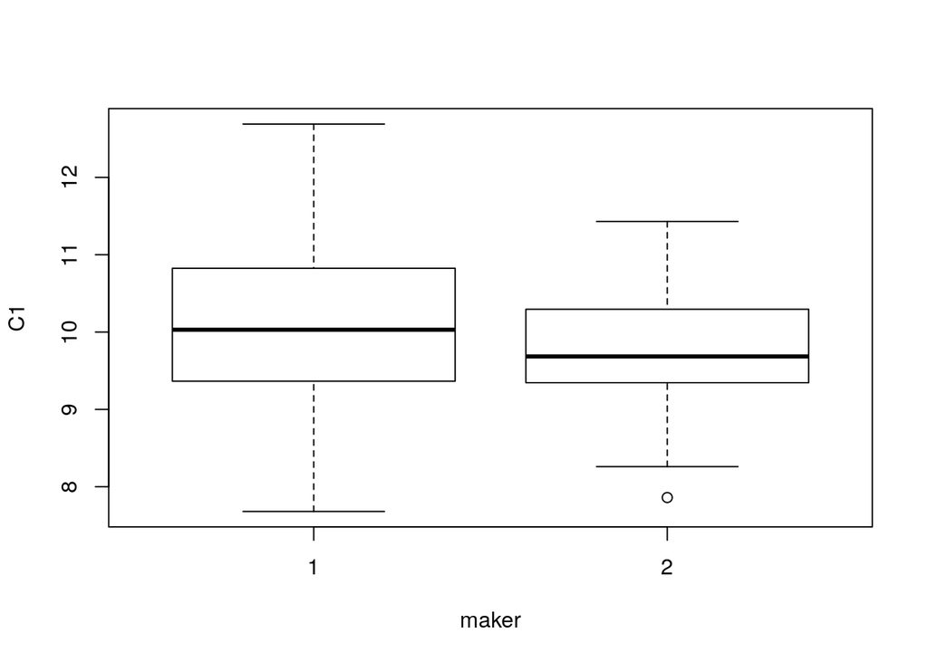

```r
boxplot(C1 ~ maker, ylab="C1", xlab="maker")
```

Построить график ядерной оценки плотности распределения (density) для анализируемой переменной.

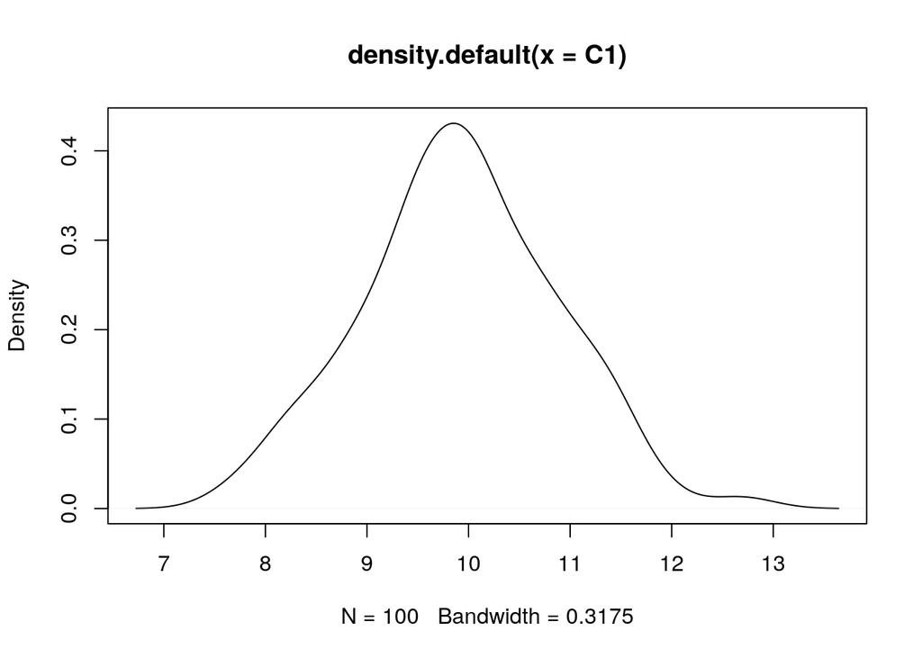

```r
plot(density(C1))
```

### Часть 5. Классификация неоднородных данных

Отсоединить таблицу данных qc от списка текущих переменных (работа с данными закончена).

```r
detach(qc)
```